# Test Assignment

2025-07-28

## The assignment

The goal of this assignment is to calculate population-weighted coverage of two health services:

- Antenatal care (ANC4): % of women (aged 15–49) with at least 4 antenatal care visits
- Skilled birth attendance (SBA): % of deliveries attended by skilled health personnel

for countries categorized as on-track or off-track in achieving under-five mortality targets (as of 2022).

## Load and transform the data

### Load On-Track and Off-Track countries

Read the excel file and re-classify the countries into On-Track and Off-Track categories, according to the following rule:

- On-track if Status.U5MR is “achieved” or “on-track”
- Off-track if Status.U5MR is “acceleration needed”

```r
track <- read_excel('../data/01_rawdata/On-track and off-track countries.xlsx')
table(track$Status.U5MR)
```

```
##
## Acceleration Needed            Achieved            On Track
##                  59                 134                   7
```

```r
track %>%
    mutate(status = ifelse(Status.U5MR %in% c('Achieved', 'On Track'), 'On-track', 'Off-track')
           ) -> track
```

Countries in this table are assigned an ISO3 Code, which we’ll use to merge with the demographic data later.

### Load and transform demographic data

The demographic is in an Excel file, and I read it with the `read_excel` function, loading only the `Projections` tab. I filter the data for the year 2022 and select only a few relevant columns, for ease of further reading.

Next, I convert the number of births from thousands to actual numbers by multiplying by 1000. Finally, I use the `countrycode` package to convert the `Location code` to ISO3 codes - this is needed for further merging across data sets. I store the result in a new data frame `demographic_proj`.

```r
demographic <- read_excel('../data/01_rawdata/WPP2022_GEN_F01_DEMOGRAPHIC_INDICATORS_COMPACT_REV1.xlsx', skip = 16,
                          sheet = 'Projections')
demographic %>%
    filter(Year == 2022) %>%
    select(`Location code`, `Births (thousands)`) %>%
    mutate(projected_births = as.numeric(`Births (thousands)`) * 1000, # NA appears due to invalid original value
           ISO3Code = countrycode(`Location code`, origin = "iso3n", destination = "iso3c")
           # warning is about broad geo areas, not countries, so we're good
           ) -> demographic_proj
```

### Load and transform indicators

This is the indicators data from UNICEF. I extract the ISO3 code and indicator name from the `REF_AREA:Geographic area` and `INDICATOR:Indicator` columns, and filter for the most recent year for each country and indicator. Finally, I convert the observation value to a share (not per cent) by dividing by 100.

```r
indicators <- read_csv('../data/02_additionaldata/fusion_GLOBAL_DATAFLOW_UNICEF_1.0_.MNCH_ANC4+MNCH_SAB..csv', show_col_types = FALSE)
indicators %>%
    rename('indicator_year' = 'TIME_PERIOD:Time period') %>%
    mutate(ISO3Code = str_extract(`REF_AREA:Geographic area`, '^.*(?=\\:)'),
           indicator = str_extract(`INDICATOR:Indicator`, '^.*(?=\\:)')) %>%
    group_by(ISO3Code, indicator) %>%
    filter(indicator_year == max(indicator_year)) %>%
    mutate(indicator_value = `OBS_VALUE:Observation Value` / 100) %>%
    select(ISO3Code, indicator, indicator_year, indicator_value) %>%
    ungroup() -> indicators
```

### Merge

I merge the `indicators`, `track` and `demographic_proj` tables by the `ISO3Code` column.

```r
indicators %>%
    inner_join(track, by = 'ISO3Code') %>%
    select(ISO3Code, OfficialName, status, indicator, indicator_year, indicator_value) %>%
    left_join(demographic_proj, by = 'ISO3Code') -> merged
```

## Calculate population-weighted coverage

Next, I calculate the population-weighted coverage for the two indicators: `MNCH_ANC4` (at least 4 antenatal care visits) and `MNCH_SAB` (births attended by skilled health personnel).

The weighted coverage is the sum of the product of indicator value and population, divided by the total population:

$$\text{Coverage}\_{\text{weighted}} = \frac{\sum_{i=1}^n (c_i \cdot
w_i)}{\sum_{i=1}^n w_i}$$
where:

- $c_i$ is the indicator coverage for country $i$
- $w_i$ is the “weight”, the projected number of births in 2022 for country $i$

In our case, population is projected births.

```r
# ANC4: % of women (aged 15–49) with at least 4 antenatal care visits
merged %>%
    filter(indicator == 'MNCH_ANC4') %>% # lower n than SAB!
    group_by(status) %>%
    summarise(population_weighted_coverage =
          sum(indicator_value * projected_births, na.rm = T) / sum(projected_births, na.rm = T)
          ) -> anc4_coverage

# SAB: % of births attended by skilled health personnel
merged %>%
    filter(indicator == 'MNCH_SAB') %>%
    group_by(status) %>%
    summarise(population_weighted_coverage =
      sum(indicator_value * projected_births, na.rm = T) / sum(projected_births, na.rm = T)
      ) -> sab_coverage

anc4_coverage
```

```
## # A tibble: 2 × 2
##   status    population_weighted_coverage
##   <chr>                            <dbl>
## 1 Off-track                        0.553
## 2 On-track                         0.728
```

```r
sab_coverage
```

```
## # A tibble: 2 × 2
##   status    population_weighted_coverage
##   <chr>                            <dbl>
## 1 Off-track                        0.687
## 2 On-track                         0.925
```

## Visualise

To compare the values easily, I created two bar plots, one for each indicator, split by On-Track and Off-Track countries.

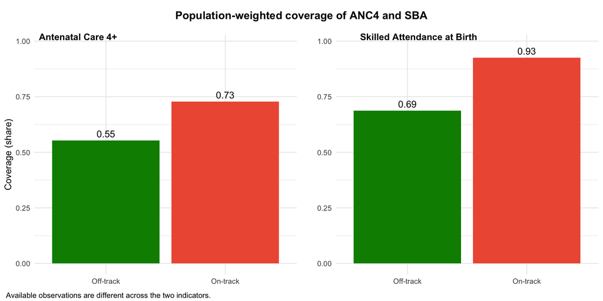

### Take-aways:

#### Antenatal Care (ANC4)

- In off-track countries, 55% of pregnant women received 4+ antenatal visits.
- In on-track countries, 73% of pregnant women received 4+ antenatal visits.

The population-weighted coverage for antenatal care (ANC4) shows a significant gap between on-track and off-track countries. This makes sense, as access to medical care during pregnancy must be strongly correlated with being on-track or off.

But even in on-track countries, there’s a gaps in continuity of care - not all pregnant women get the full recommended number of visits. So even among countries with good health systems (on-track), drop-offs happen, most likely among marginalized social groups.

#### Skilled Birth Attendance (SAB)

- In off-track countries, 68.7% of deliveries are attended by skilled personnel.
- In on-track: 92.5% - consistent with this status.

These numbers show what you’d expect: almost universal skilled attendance at birth in on-track countries, with large gap in off-track ones.

#### Conclusion

On-track countries have higher population-weighted coverage for both antenatal care and skilled attendance at birth compared to off-track countries - which was expected, because child survival must be correlated with the quality of care during and after birth.

Interestingly, while skilled attendance at birth is nearly universal in on-track countries, antenatal care is only 73%: countries do achieve the on-track status while having a rather low antenatal care coverage.

As a hypothesis, the ANC4 indicator may be capturing two opposing dynamics: access to antenatal services and the need to seek them. In off-track countries, where health systems are weaker and risks to child health are higher (lower vaccination rates, poorer baseline health, exposure violent conflict, etc.), the need for antenatal care should be greater. Yet access is limited.

In contrast, in on-track countries where new-born health risks are lower and basic services are more universal, the urgency of antenatal care is reduced. This could partly explain why ANC4 coverage does not reach 100% even in countries with strong health systems and high skilled birth attendance. In this sense, ANC4 coverage probably reflects a mix of supply-side (how available medical care is) and also risk environments (the need to seek care in the first place).

Note also that we observe less data for ANC4 than for SAB, so the ANC4 results are somewhat less reliable.

### Positions I’m considered for:

- Learning and Skills Data Analyst Consultant - Req 581598
- Roster of quantitative and qualitative research consultants: Social & Economic Policy unit - Req 580413
- Data Analytics and Statistical support Consultancy/Monitoring Unit - Req 581443
- Long-Term Agreement (LTA) for Household Survey & Sampling Expert Consultants, Data and Analytics (D&A) - Req 581382